# PSTAT 126 Project Summary

Minu Pabbathi, Ziqian Zhao, Paul Zhang

2024-06-11

# About the data

This data set dates from 1988 and consists of four databases: Cleveland, Hungary, Switzerland, and Long Beach V. It contains information about patients and risks for heart disease as well as whether or not they eventually end up developing heart disease. The data set originally contains 1025 observations. For the sake of clearness of the scatter plot, we randomly choose 500 from the original dataset.

# Data Description

The `age` variable is a numeric variable that lists the age of the patient in years. The `sex` variable is a binary variable that states the sex of the patient, with 0 representing female and 1 representing male. The `cp` variable is a categorical variable that classifies the type of chest pain the patient is experiencing; 0 represents typical angina, 1 represents atypical angina, 2 represents non-anginal pain, and 3 represents asymptomatic. The `trestbps` variable is a numeric variable that states the resting blood pressure in mmHg.

The `chol` variable is a numeric data which give an overview of person’s cholesterol levels. The `fbs` variable is a binary data with 1 means the fast blood sugar is greater than 120mg/dl, and 0 means the fast blood sugar is not. The `restecg` variable is a nominal data with scale of 0 (normal), 1 (abnormality in ST-T waves), and 2 (show left ventricular hypertrophy), which record the resting electrocardiogram results. The `thalach` variable is a numeric data which records the maximum heart rate achieved.

The variable `exang` indicates that if the patient have exercise induced angina (chest pain), which is shown with 0 indicating “no” and 1 indicating “yes”. The variable `oldpeak` is a float type data records the ST depression, which is a measure of abnormality of an electrocardiogram, and the measurement is in unit depression. The variable `slope` is the slope of the peak exercise ST segment, which is an electrocardiography read out indicating quality of blood flow to the heart, and the data are in nominal type including 0 (upsloping), 1 (flat) and 2 (downsloping). Finally, the variable `target` is a binary data showing whether the patient is having heart disease (1 = having heart disease and 0 = normal).

# Summary Statistics and Graphs

Data summary

| Name | heart_disease_data |
| --- | --- |
| Number of rows | 500 |
| Number of columns | 14 |
| _______________________ |  |
| Column type frequency: |  |
| factor | 7 |
| numeric | 7 |
| ________________________ |  |
| Group variables | None |

**Variable type: factor**

| skim_variable | n_missing | complete_rate | ordered | n_unique | top_counts |
| --- | --- | --- | --- | --- | --- |
| sex | 0 | 1 | FALSE | 2 | 1: 355, 0: 145 |
| cp | 0 | 1 | FALSE | 4 | 0: 223, 2: 159, 1: 86, 3: 32 |
| fbs | 0 | 1 | FALSE | 2 | 0: 418, 1: 82 |
| restecg | 0 | 1 | FALSE | 3 | 0: 263, 1: 233, 2: 4 |
| exang | 0 | 1 | FALSE | 2 | 0: 330, 1: 170 |
| slope | 0 | 1 | FALSE | 3 | 2: 238, 1: 227, 0: 35 |
| target | 0 | 1 | FALSE | 2 | 1: 266, 0: 234 |

**Variable type: numeric**

| skim_variable | n_missing | complete_rate | mean | sd | p0 | p25 | p50 | p75 | p100 | hist |
| --- | --- | --- | --- | --- | --- | --- | --- | --- | --- | --- |
| age | 0 | 1 | 54.02 | 9.22 | 29 | 47 | 55.0 | 60.25 | 77.0 | ▁▆▇▇▁ |
| trestbps | 0 | 1 | 132.46 | 18.06 | 94 | 120 | 130.0 | 140.00 | 200.0 | ▃▇▅▂▁ |
| chol | 0 | 1 | 248.13 | 55.44 | 126 | 211 | 243.0 | 282.00 | 564.0 | ▃▇▂▁▁ |
| thalach | 0 | 1 | 150.19 | 23.31 | 71 | 137 | 152.0 | 168.00 | 202.0 | ▁▂▅▇▂ |
| oldpeak | 0 | 1 | 1.03 | 1.17 | 0 | 0 | 0.8 | 1.60 | 6.2 | ▇▂▁▁▁ |
| ca | 0 | 1 | 0.76 | 1.07 | 0 | 0 | 0.0 | 1.00 | 4.0 | ▇▃▂▁▁ |
| thal | 0 | 1 | 2.29 | 0.63 | 0 | 2 | 2.0 | 3.00 | 3.0 | ▁▁▁▇▆ |

# Correlation

The following correlation matrix represent the relationship between different variables and the interaction between each other.

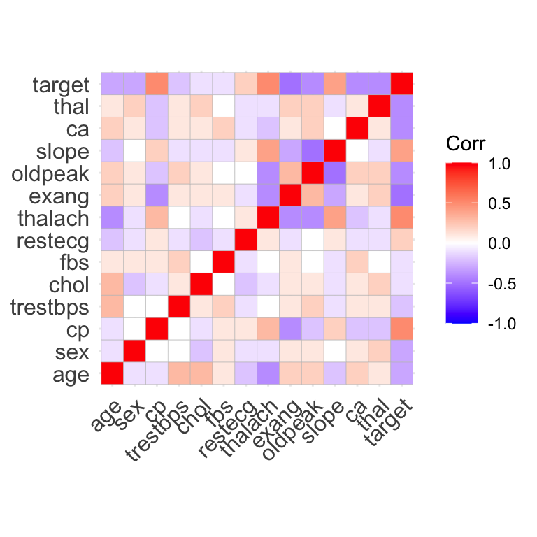

# Statistical Approach for Selecting OLS Model

We used a forward step-wise model, meaning we assumed no relationship between the variables, and then added predictors one by one until no other significant predictors were left.

Our criteria for choosing the variables is based on the AIC, meaning that starting with an intercept-only model, we add the variable with the lowest AIC value at a time, then re-examine the new model to find the next variable until no variables significant.

## Finding $R^2$ of Predicted Values

About 49% of the variance in maximum heart rate in the test data is accounted for by the slope of the peak exercise ST segment, age, chest pain type, exercise-induced angina, heart disease, resting blood pressure, and resting ecg.

```
## [1] "R-square value on test data: 0.493739305422597"
```

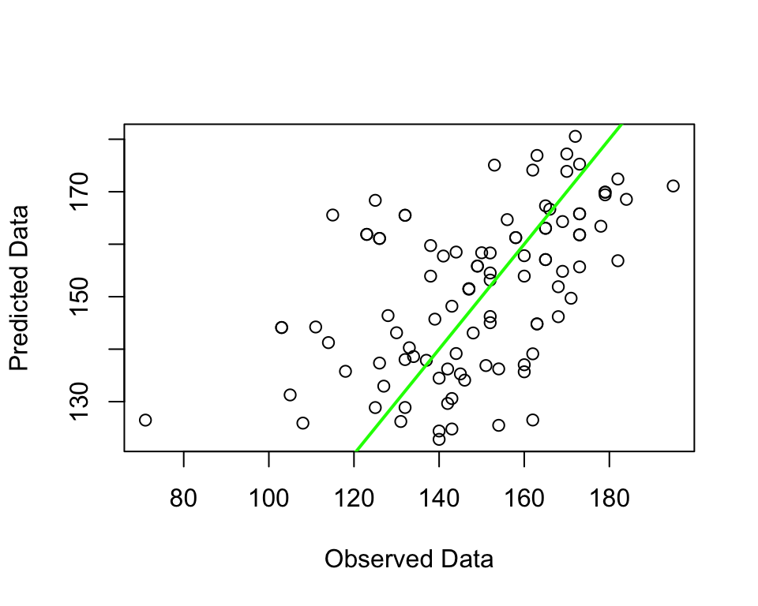

Plotting Predictions for OLS Model

# Checking Influential Points of OLS Model

To check outliers, leverage points, and influence points, we created graphs of the residuals, the diagonal values of the hat matrix, and Cook’s distance. In each graph, we selected the largest value in red to visualize it on each plot.

The residuals appear randomly scattered with equal variance and no obvious pattern, and based on the Q-Q plot, are approximately normal, indicating that the model is a good fit.

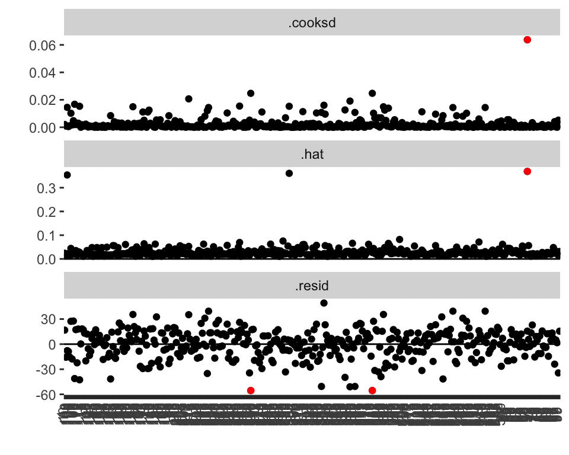

Influential Points Analysis

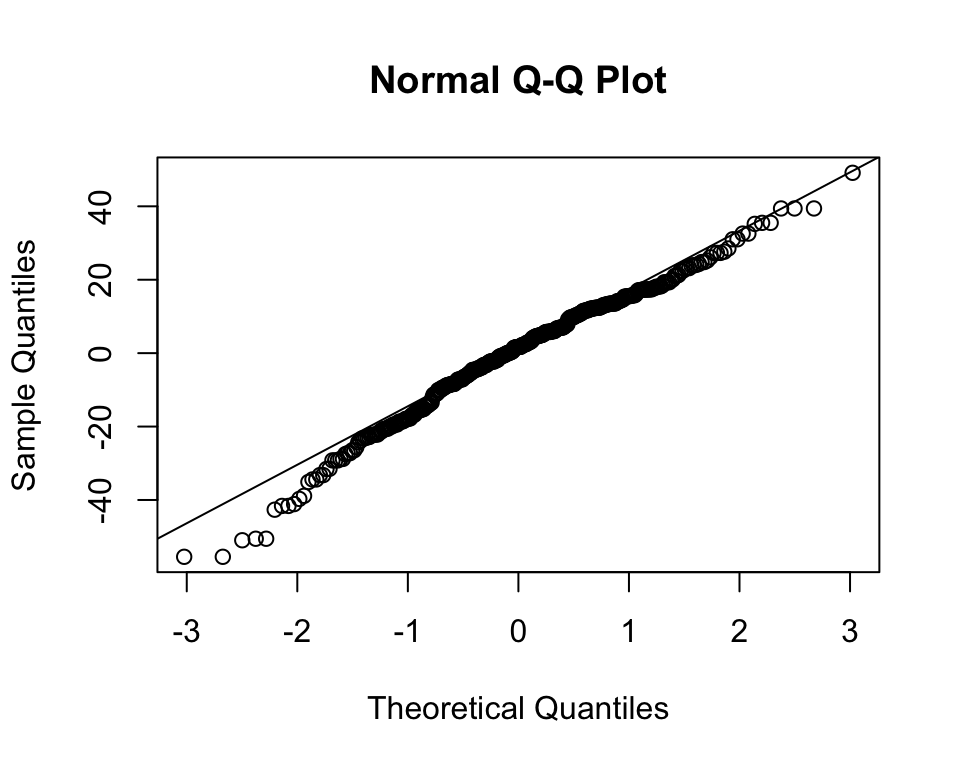

Q-Q Plot of Residuals

# Shrinkage Methods

## LASSO Regression

LASSO regression is a type of linear regression that is used for shrinkage and variable selection. A penalty term equivalent to the absolute value of the coefficients times a tuning parameter $\lambda$ is added to discourage large values of $\beta$. As a result, some coefficients are shrunk to 0, making LASSO a useful tool for variable selection. Thus, finding an optimal $\lambda$ is crucial to maintaining a balance between shrinkage and a usable model. Additionally, by introducing bias through the penalty term, LASSO regression can decrease the variance of the coefficient estimates, leading to a lower out-of-sample MSE and better generalization.

Here, $\lambda$ is selected by testing a grid of potential values and then conducting 10-fold cross validation to determine which value minimizes the test MSE. Fig. 1 plots the test MSE against potential $\lambda$ values. Using the calculated optimal $\lambda$, we fit the final model.

```
## [1] "Best lambda: 0.310161341566227"
```

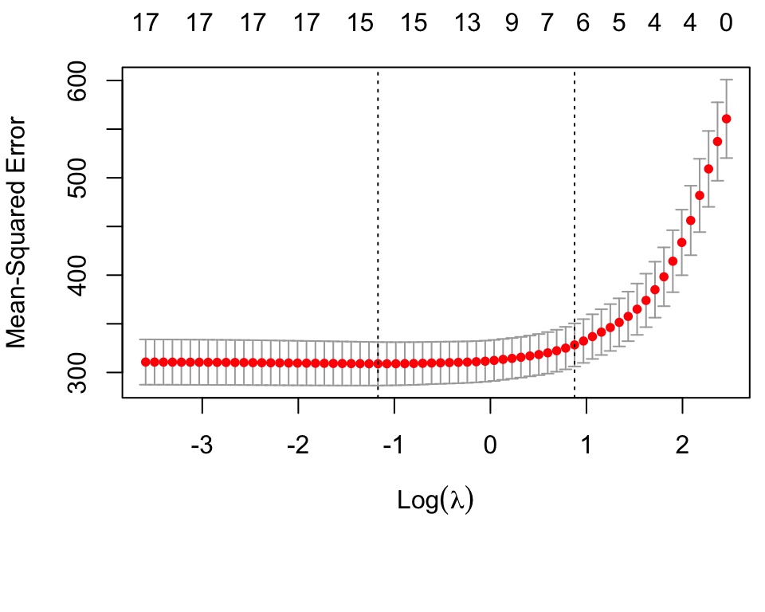

MSE vs. Lambda

## Ridge Regression

Ridge model is a method of estimating the coefficients of multi-variable linear regression.Different from Ordinary Least Square(OLS) method, Ridge regression, including a penalty term, provides a trade-off between variance and bias, which are the two criteria for MSE what we want to minimize.

Here, we fit a Ridge regression with the optimal lambda found through cross validation

```
## [1] "By cross validation between 10 folds, the optimal lambda is 3.2493"
```

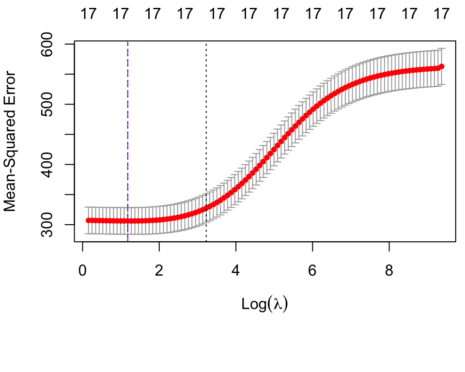

MSE vs. Lambda

Fig. 3 visualized how MSE change with the regularization parameter $\lambda$. As our goal is to minimize MSE, we locate the $log(\lambda)$ correspond to the smallest MSE, which shown by the purple line and select the lambda as the regularization factor.

We then fit the model with the penalty term and obtain the estimated coefficients. In terms of variable selection, more variables are considered significant than forward step-wise selection (the method used previous). Specifically, `oldpeak`,`ca`, and `thal` are also considered as significant (the |coefficient| > 0.5).

## Making Combined Plot

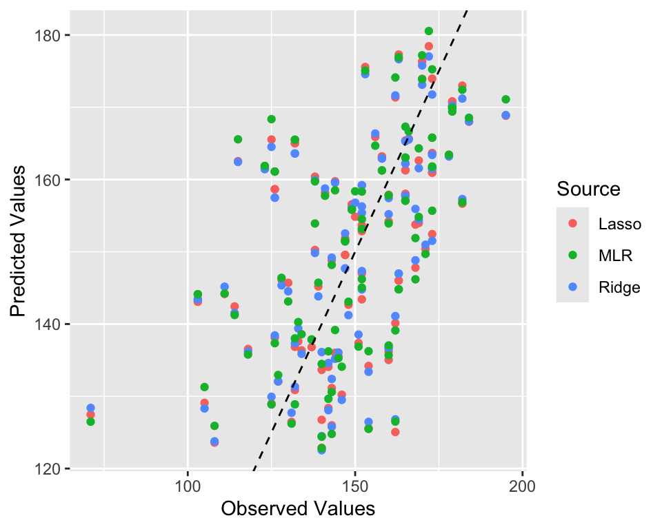

Combined Plot

## Model Comparison

The plot shows that the predictions between three models do not differentiate much. Specifically, the observations of three models, represented by three different colors, located close to each other along the line $y=x$.

Specifically, dots of LASSO (red) and Ridge(blue) are closely located together and the small deviation could be caused by differences between the penalty term (i.e. $\lambda$).

The dots of OLS(green) deviated relatively more from the others which could be a result of different predictor selection. Specifically, lasso and ridge regression consider three more variables significant. However, the deviation is not significant, so it is reasonable to conclude that predictor are consistently selected.

| Predictors | Lasso | Ridge | MLR |
| --- | --- | --- | --- |
| Age | -6.99 | -6.34 | 0 |
| Sex = 1 | 0 | -0.29 | 0 |
| Chest Pain type =1 | 8.89 | 8.66 | 10.56 |
| Chest Pain type=2 | 3.87 | 4.03 | 5.17 |
| Chest Pain type=3 | 13.43 | 13.03 | 15.11 |
| Rest bps | 1.67 | 1.60 | 0.12 |
| Serum Cholesterol | 0.22 | 0.31 | 0 |
| Fasting blood sugar =1 | 0 | 0.31 | 0 |
| Rest ecg=1 | -2.14 | -2.22 | -3.18 |
| Rest ecg=2 | -7.69 | -10.12 | -12.76 |
| Exercise angina=1 | -8.47 | -8.12 | -8.35 |
| oldpeak | -0.81 | -1.39 | 0 |
| ST slpoe =1 | -7.18 | -4.33 | -1.16 |
| ST slope =2 | 9.98 | 7.37 | 11.27 |
| Target =1 | 6.29 | 6.12 | 6.43 |

From the table above, which shows the estimated coefficients from three regression methods, it further convinced that the coefficients are inherently and similarly estimated.

# Innovation

Since we then need a linear regression to estimate the coefficient, we then apply log map the probability to real number for linear regression, that is
$$Logit(p) =
log(\frac{p}{1-p})$$

Apply $logit(p)$ as the new response and fit a linear model with the predictor variables.

$$Logit(p) = \beta_0 + \beta_1x_1+\beta_2x_2+\cdots+\beta_nx_n$$

Then we inverse the logit to get $p$, namely,
$$p = \frac{1}{1+e^{-(\beta_0 + \beta_1x_1+\beta_2x_2+\cdots+\beta_nx_n)}}$$

## Technical Conditions

1. The response variable is binary. This fits our model that the response is the target variable, which indicates whether the patient have heart disease.
2. The model should have minimal multicollinearity. The LASSO regression is removing predictors that are having high correlations.
3. Sufficient sample size and independent observation. Our dataset is large and the patients conditions are independent.
4. There shouldn’t be prefect separation. We don’t have some predictors that can precisely predict the outcome.
5. There shouldn’t be highly influential outliners. For this one we didn’t particularly remove the outliners.

## Method Justification

To explore further models, we decided to use logistic regression since we were interested in seeing how the variables can be used to predict heart disease, or the `target` variable. Since heart disease is a binary variable, OLS, ridge, and LASSO cannot be used since the response variable in these cases must be continuous.

## Fitting Logistic Model

First, we used LASSO to determine which variables to include in the model. Based on the results from the LASSO regression, we fit a logistic model using the non-zero coefficients.

```
##
## Call:
## glm(formula = target ~ age + sex + cp + trestbps + fbs + restecg +
##     thalach + exang + slope + ca + thal, family = binomial, data = train_data)
##
## Coefficients:
##              Estimate Std. Error z value Pr(>|z|)
## (Intercept)  3.215911   2.691304   1.195  0.23212
## age         -0.013983   0.023098  -0.605  0.54493
## sex1        -2.011873   0.445663  -4.514 6.35e-06 ***
## cp1          0.838787   0.482932   1.737  0.08241 .
## cp2          2.817552   0.506933   5.558 2.73e-08 ***
## cp3          3.350009   0.717658   4.668 3.04e-06 ***
## trestbps    -0.017784   0.009636  -1.846  0.06496 .
## fbs1        -0.539926   0.491566  -1.098  0.27204
## restecg1     0.540507   0.351903   1.536  0.12455
## restecg2    -0.380370   2.182778  -0.174  0.86166
## thalach      0.019662   0.011372   1.729  0.08381 .
## exang1      -0.853594   0.419316  -2.036  0.04178 *
## slope1       0.173169   0.746474   0.232  0.81655
## slope2       2.248040   0.765454   2.937  0.00332 **
## ca          -1.116049   0.193442  -5.769 7.95e-09 ***
## thal        -1.307612   0.284819  -4.591 4.41e-06 ***
## ---
## Signif. codes:  0 '***' 0.001 '**' 0.01 '*' 0.05 '.' 0.1 ' ' 1
##
## (Dispersion parameter for binomial family taken to be 1)
##
##     Null deviance: 552.83  on 399  degrees of freedom
## Residual deviance: 235.42  on 384  degrees of freedom
## AIC: 267.42
##
## Number of Fisher Scoring iterations: 6
```

## ROC Curve

A tool to visualize logistic regression is a ROC (Receiver Operating Characteristic) curve, in which the true positive rate (sensitivity) is plotted against the false positive rate (1 - specificity) at different threshold values. The closer the ROC curve is to the top-left corner, the better the model is at distinguishing between positive and negative classes. A model with no discriminative power will have an ROC curve along the diagonal line, essentially equivalent to random guessing. As can be seen in Fig. 6, the ROC curve is relatively close to the top-left corner, indicating that the model has high sensitivity and high specificity.

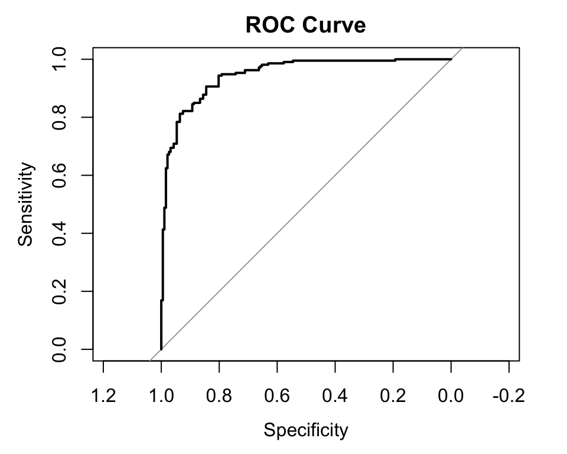

ROC Curve for logisitic model

## AUC

The AUC, or area under the curve, is a measure of how well the model is able to discriminate between positive and negative cases. The AUC ranges from 0 to 1, with the following interpretations:

- < 0.5: No discriminative power (equivalent to random guessing).
- 0.5 - 0.7: Poor discrimination.
- 0.7 - 0.8: Acceptable discrimination.
- 0.8 - 0.9: Excellent discrimination.
- > 0.9: Outstanding discrimination.

```
## [1] "AUC: 0.947176822073259"
```

Since the AUC is above 0.9, we can conclude that our model is highly accurate at distinguishing between cases.

## Optimal Threshold Value

Based on the ROC curve, we can determine the optimal threshold value, which is the value that maximizes the distance from the diagonal line (representing random chance) or maximizes the area under the ROC curve (AUC). If the predicted probability is less than the threshold, then the response can be classified as 0, or no heart disease. If the predicted probability is greater than threshold, then the response can be classified as 1, or having heart disease.

```
## [1] "Optimal threshold value: 0.524617014252765"
```

## Conclusion

After applying RR and LASSO to our model, we have found similarly selected predictors, and also the predictions are generally promising compared to observed data. When compared with the model we had from MLR, several predictors are reconsidered and we still have relatively consistent predicted result. It is also noteworthy that when looking at the superimposed graph, we had outliners that distributing similarly across three methods, which indicating that further steps are needed to take care of them.